# Sesión 4

Ana Escoto

30/10/2021

## Previo

Volvamos a la base de la EHPM.

```stata
use "datos/ehpm_2019", clear
```

Transformación logaritmica

```stata
gen log_money=log(money) if actpr2012==10
```

```
(47,267 missing values generated)
```

Con este modelo empezamos la sesión pasada. Lo corremos para tenerlo en la memoria

```stata
regress log_money aproba1 i.r104 ib5.region r106 if actpr2012==10
estimates store modelo4
```

```
      Source |       SS           df       MS      Number of obs   =    27,181
-------------+----------------------------------   F(7, 27173)     =   1231.28
       Model |  3764.39125         7  537.770179   Prob > F        =    0.0000
    Residual |       11868    27,173  .436757075   R-squared       =    0.2408
-------------+----------------------------------   Adj R-squared   =    0.2406
       Total |  15632.3913    27,180  .575143166   Root MSE        =    .66088

------------------------------------------------------------------------------
   log_money | Coefficient  Std. err.      t    P>|t|     [95% conf. interval]
-------------+----------------------------------------------------------------
     aproba1 |   .0697546   .0008845    78.87   0.000      .068021    .0714882
        r104 |
      mujer  |  -.3017288   .0081353   -37.09   0.000    -.3176745   -.2857831
      region |
 occidental  |  -.1438722   .0132228   -10.88   0.000    -.1697896   -.1179547
  central i  |  -.1231996    .013113    -9.40   0.000    -.1489017   -.0974975
 central ii  |  -.1624411    .014404   -11.28   0.000    -.1906736   -.1342085
   oriental  |  -.1747649   .0134767   -12.97   0.000      -.20118   -.1483498
        r106 |    .009887   .0002954    33.47   0.000      .009308     .010466
       _cons |   4.798866   .0198346   241.94   0.000     4.759989    4.837743
------------------------------------------------------------------------------
```

# Extensión de modelos (efectos cuadráticos e interacciones)

## Efecto cuadrático de la escolaridad en los ingresos

Recordemos las relaciones gráficas

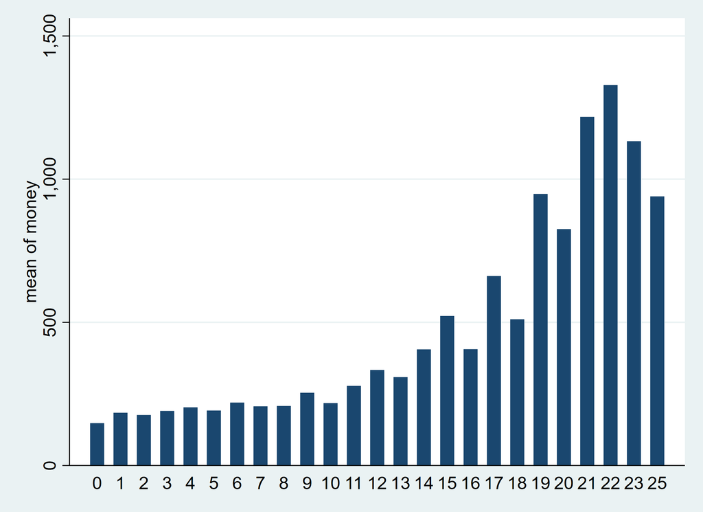

```stata
graph bar (mean) money if actpr2012==10, over(aproba1)
```

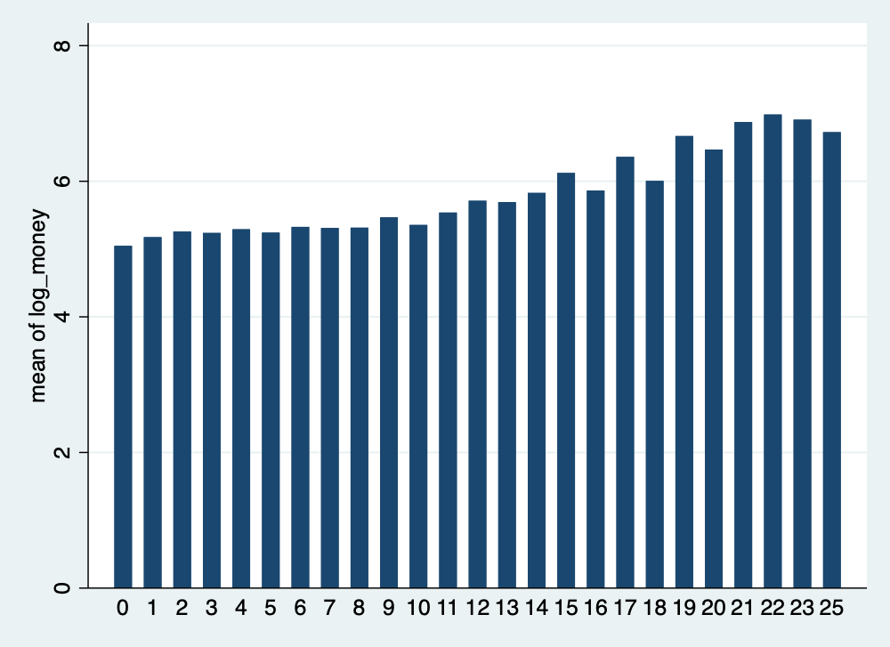

```stata
graph bar (mean) log_money if actpr2012==10, over(aproba1)
```

Tan a nivel como en logaritmo, podemos ver un efecto un ligero efecto acelaración. Estos efectos normalmente se introducen como valores cuadráticos. Veamos, creamos las variables

```stata
gen aproba2=aproba1^2
```

```
(4,572 missing values generated)
```

Ahora veamos su relación con con un *scatterplot*

```stata
twoway scatter log_money aproba2 if actpr2012==10, jitter(50)  mcolor(%20)
```

[figure not shown]

```stata
pwcorr log_money aproba* if actpr2012==10, sig obs
```

```
             | log_mo~y  aproba1  aproba2
-------------+---------------------------
   log_money |   1.0000
             |    27181
     aproba1 |   0.4098   1.0000
             |   0.0000
             |    27181    32258
     aproba2 |   0.4317   0.9484   1.0000
             |   0.0000   0.0000
             |    27181    32258    32258
```

Corremos otro modelo con el efecto cuadratico

```stata
regress log_money aproba1 aproba2 i.r104 ib5.region r106 if actpr2012==10
estimates store modelo5
```

```
      Source |       SS           df       MS      Number of obs   =    27,181
-------------+----------------------------------   F(8, 27172)     =   1149.59
       Model |  3953.03702         8  494.129627   Prob > F        =    0.0000
    Residual |  11679.3542    27,172  .429830496   R-squared       =    0.2529
-------------+----------------------------------   Adj R-squared   =    0.2527
       Total |  15632.3913    27,180  .575143166   Root MSE        =    .65561

------------------------------------------------------------------------------
   log_money | Coefficient  Std. err.      t    P>|t|     [95% conf. interval]
-------------+----------------------------------------------------------------
     aproba1 |   .0143285   .0027874     5.14   0.000      .008865    .0197919
     aproba2 |   .0033159   .0001583    20.95   0.000     .0030056    .0036261
        r104 |
      mujer  |  -.3128858   .0080881   -38.68   0.000    -.3287389   -.2970326
      region |
 occidental  |  -.1415599    .013118   -10.79   0.000    -.1672719   -.1158479
  central i  |  -.1130063   .0130177    -8.68   0.000    -.1385216    -.087491
 central ii  |  -.1585421   .0142905   -11.09   0.000    -.1865523   -.1305319
   oriental  |  -.1841687    .013377   -13.77   0.000    -.2103883   -.1579491
        r106 |   .0083257   .0003024    27.53   0.000      .007733    .0089183
       _cons |   5.016032   .0222403   225.54   0.000      4.97244    5.059624
------------------------------------------------------------------------------
```

```stata
ftest modelo4 modelo5
```

```
Assumption: modelo4 nested in modelo5

F(  1,   27172) =    438.88
       prob > F =    0.0000
```

No obstante, el modelo 5 es un poco problemático para calcular el efecto acumulado de la escolaridad, o el efecto promedio.

Corremos otro modelo con el efecto cuadratico

```stata
estimates restore modelo5
margins, dydx(aproba*)
```

```
(results modelo5 are active now)


Average marginal effects                                Number of obs = 27,181
Model VCE: OLS

Expression: Linear prediction, predict()
dy/dx wrt:  aproba1 aproba2

------------------------------------------------------------------------------
             |            Delta-method
             |      dy/dx   std. err.      t    P>|t|     [95% conf. interval]
-------------+----------------------------------------------------------------
     aproba1 |   .0143285   .0027874     5.14   0.000      .008865    .0197919
     aproba2 |   .0033159   .0001583    20.95   0.000     .0030056    .0036261
------------------------------------------------------------------------------
```

¿Cómo podríamos tener un efecto marginal que de cuenta de las dos variables como una sola?

Vamos a introduci otro prefijo de variable que es “c.”

Corremos otro modelo con el efecto cuadratico

```stata
regress log_money c.aproba1##c.aproba1 i.r104 ib5.region r106 if actpr2012==10
estimates store modelo6
```

```
      Source |       SS           df       MS      Number of obs   =    27,181
-------------+----------------------------------   F(8, 27172)     =   1149.59
       Model |  3953.03702         8  494.129627   Prob > F        =    0.0000
    Residual |  11679.3542    27,172  .429830496   R-squared       =    0.2529
-------------+----------------------------------   Adj R-squared   =    0.2527
       Total |  15632.3913    27,180  .575143166   Root MSE        =    .65561

-------------------------------------------------------------------------------------
          log_money | Coefficient  Std. err.      t    P>|t|     [95% conf. interval]
--------------------+----------------------------------------------------------------
            aproba1 |   .0143285   .0027874     5.14   0.000      .008865    .0197919
c.aproba1#c.aproba1 |   .0033159   .0001583    20.95   0.000     .0030056    .0036261
               r104 |
             mujer  |  -.3128858   .0080881   -38.68   0.000    -.3287389   -.2970326
             region |
        occidental  |  -.1415599    .013118   -10.79   0.000    -.1672719   -.1158479
         central i  |  -.1130063   .0130177    -8.68   0.000    -.1385216    -.087491
        central ii  |  -.1585421   .0142905   -11.09   0.000    -.1865523   -.1305319
          oriental  |  -.1841687    .013377   -13.77   0.000    -.2103883   -.1579491
               r106 |   .0083257   .0003024    27.53   0.000      .007733    .0089183
              _cons |   5.016032   .0222403   225.54   0.000      4.97244    5.059624
-------------------------------------------------------------------------------------
```

Corremos otro modelo con el efecto cuadratico

```stata
estimates restore modelo6
margins, dydx(aproba1)
```

```
(results modelo6 are active now)


Average marginal effects                                Number of obs = 27,181
Model VCE: OLS

Expression: Linear prediction, predict()
dy/dx wrt:  aproba1

------------------------------------------------------------------------------
             |            Delta-method
             |      dy/dx   std. err.      t    P>|t|     [95% conf. interval]
-------------+----------------------------------------------------------------
     aproba1 |   .0682883   .0008802    77.58   0.000      .066563    .0700135
------------------------------------------------------------------------------
```

## Interacciones

Los ## nos sirven para tener las interacciones. También nos sirven para ver interacciones de varios tipos

### Cuali y cuanti

```stata
regress log_money c.aproba1##i.r104 ib5.region r106 if actpr2012==10
estimates store modelo7
```

```
      Source |       SS           df       MS      Number of obs   =    27,181
-------------+----------------------------------   F(8, 27172)     =   1087.35
       Model |  3790.90328         8   473.86291   Prob > F        =    0.0000
    Residual |   11841.488    27,172  .435797438   R-squared       =    0.2425
-------------+----------------------------------   Adj R-squared   =    0.2423
       Total |  15632.3913    27,180  .575143166   Root MSE        =    .66015

--------------------------------------------------------------------------------
     log_money | Coefficient  Std. err.      t    P>|t|     [95% conf. interval]
---------------+----------------------------------------------------------------
       aproba1 |   .0637174   .0011746    54.25   0.000     .0614152    .0660197
          r104 |
        mujer  |  -.4072198   .0157786   -25.81   0.000    -.4381466    -.376293
r104#c.aproba1 |
        mujer  |   .0129382   .0016588     7.80   0.000     .0096869    .0161895
        region |
   occidental  |  -.1440278   .0132083   -10.90   0.000    -.1699168   -.1181388
    central i  |  -.1229838   .0130986    -9.39   0.000    -.1486577     -.09731
   central ii  |  -.1642713   .0143901   -11.42   0.000    -.1924765    -.136066
     oriental  |  -.1770857   .0134652   -13.15   0.000    -.2034782   -.1506932
          r106 |   .0100006   .0002954    33.85   0.000     .0094216    .0105797
         _cons |   4.844602   .0206623   234.47   0.000     4.804103    4.885102
--------------------------------------------------------------------------------
```

Vamos a ver esto en qué se puede traducir, veamos cómo se predicen los efectos de los años de escolaridad para el modelo 4 y luego para el modelo 7

```
(results modelo4 are active now)


Predictive margins                                      Number of obs = 27,181
Model VCE: OLS

Expression: Linear prediction, predict()
1._at: aproba1 =  0
2._at: aproba1 =  4
3._at: aproba1 =  8
4._at: aproba1 = 12
5._at: aproba1 = 16
6._at: aproba1 = 20
7._at: aproba1 = 24

------------------------------------------------------------------------------
             |            Delta-method
             |     Margin   std. err.      t    P>|t|     [95% conf. interval]
-------------+----------------------------------------------------------------
    _at#r104 |
   1#hombre  |   5.055708   .0088987   568.14   0.000     5.038266     5.07315
    1#mujer  |   4.753979   .0095174   499.50   0.000     4.735324    4.772634
   2#hombre  |   5.334726   .0064129   831.87   0.000     5.322157    5.347296
    2#mujer  |   5.032997   .0071915   699.86   0.000     5.018902    5.047093
   3#hombre  |   5.613745   .0053006  1059.07   0.000     5.603355    5.624134
    3#mujer  |   5.312016   .0061551   863.02   0.000     5.299951     5.32408
   4#hombre  |   5.892763   .0063325   930.57   0.000     5.880351    5.905175
    4#mujer  |   5.591034   .0070062   798.01   0.000     5.577302    5.604767
   5#hombre  |   6.171781   .0087827   702.72   0.000     6.154567    6.188996
    5#mujer  |   5.870053   .0092369   635.50   0.000     5.851948    5.888157
   6#hombre  |     6.4508   .0117985   546.75   0.000     6.427674    6.473926
    6#mujer  |   6.149071   .0121073   507.88   0.000      6.12534    6.172802
   7#hombre  |   6.729818   .0150435   447.36   0.000     6.700332    6.759304
    7#mujer  |   6.428089   .0152606   421.22   0.000     6.398178    6.458001
------------------------------------------------------------------------------


Variables that uniquely identify margins: aproba1 r104
```

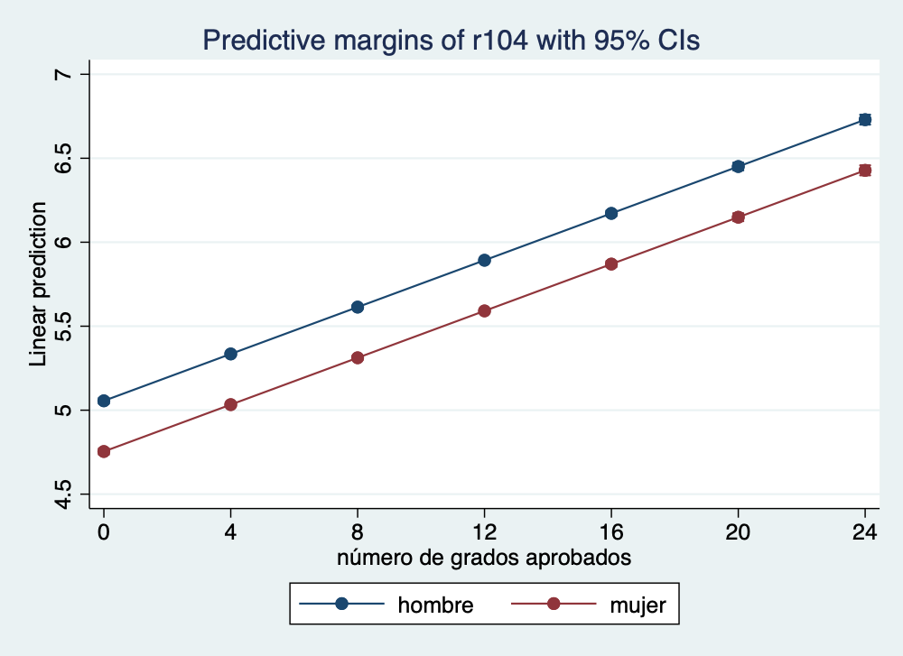

```stata
estimates restore modelo4
margins r104, at(aproba1=(0(4)25))
marginsplot
```

Veamos con el modelo de interacción

```
(results modelo7 are active now)


Predictive margins                                      Number of obs = 27,181
Model VCE: OLS

Expression: Linear prediction, predict()
1._at: aproba1 =  0
2._at: aproba1 =  4
3._at: aproba1 =  8
4._at: aproba1 = 12
5._at: aproba1 = 16
6._at: aproba1 = 20
7._at: aproba1 = 24

------------------------------------------------------------------------------
             |            Delta-method
             |     Margin   std. err.      t    P>|t|     [95% conf. interval]
-------------+----------------------------------------------------------------
    _at#r104 |
   1#hombre  |   5.105066   .0109115   467.86   0.000     5.083679    5.126453
    1#mujer  |   4.697846   .0119237   393.99   0.000     4.674475    4.721218
   2#hombre  |   5.359936   .0071751   747.02   0.000     5.345872       5.374
    2#mujer  |   5.004469   .0080611   620.82   0.000     4.988669    5.020269
   3#hombre  |   5.614806   .0052965  1060.09   0.000     5.604424    5.625187
    3#mujer  |   5.311092   .0061495   863.66   0.000     5.299038    5.323145
   4#hombre  |   5.869676   .0069838   840.47   0.000     5.855987    5.883364
    4#mujer  |   5.617714   .0077897   721.17   0.000     5.602446    5.632983
   5#hombre  |   6.124545   .0106604   574.52   0.000     6.103651     6.14544
    5#mujer  |   5.924337   .0115573   512.61   0.000     5.901684     5.94699
   6#hombre  |   6.379415   .0149219   427.52   0.000     6.350168    6.408663
    6#mujer  |    6.23096   .0160154   389.06   0.000     6.199569     6.26235
   7#hombre  |   6.634285   .0193863   342.21   0.000     6.596287    6.672283
    7#mujer  |   6.537582    .020723   315.48   0.000     6.496964      6.5782
------------------------------------------------------------------------------


Variables that uniquely identify margins: aproba1 r104
```

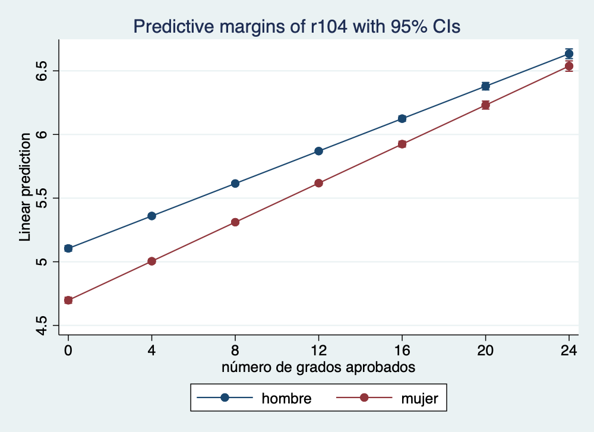

```stata
estimates restore modelo7
margins r104, at(aproba1=(0(4)25))
marginsplot
```

### Cuali y cuali

De nuevo, usamos los “##” para indicar las interacciones. Acá es hay que tener claro que hay dobles categorías de referencia: la combinación de ambas.

```stata
regress log_money aproba1 i.r104##ib5.region r106 if actpr2012==10
estimates store modelo8
```

```
      Source |       SS           df       MS      Number of obs   =    27,181
-------------+----------------------------------   F(11, 27169)    =    784.83
       Model |  3769.51926        11  342.683569   Prob > F        =    0.0000
    Residual |   11862.872    27,169  .436632633   R-squared       =    0.2411
-------------+----------------------------------   Adj R-squared   =    0.2408
       Total |  15632.3913    27,180  .575143166   Root MSE        =    .66078

-----------------------------------------------------------------------------------
        log_money | Coefficient  Std. err.      t    P>|t|     [95% conf. interval]
------------------+----------------------------------------------------------------
          aproba1 |   .0696711    .000885    78.73   0.000     .0679365    .0714057
             r104 |
           mujer  |  -.2790907   .0199549   -13.99   0.000    -.3182033    -.239978
           region |
      occidental  |  -.1181965   .0174392    -6.78   0.000    -.1523782   -.0840148
       central i  |  -.1052724   .0174778    -6.02   0.000    -.1395299    -.071015
      central ii  |  -.1676344   .0191302    -8.76   0.000    -.2051306   -.1301382
        oriental  |  -.1723192   .0178837    -9.64   0.000    -.2073721   -.1372662
      r104#region |
mujer#occidental  |  -.0609188   .0261146    -2.33   0.020    -.1121048   -.0097329
 mujer#central i  |  -.0409196   .0260445    -1.57   0.116    -.0919682    .0101291
mujer#central ii  |    .013186   .0285724     0.46   0.644    -.0428174    .0691895
  mujer#oriental  |  -.0046721   .0266397    -0.18   0.861    -.0568872     .047543
             r106 |    .009876   .0002955    33.42   0.000     .0092968    .0104551
            _cons |   4.789918   .0216073   221.68   0.000     4.747566    4.832269
-----------------------------------------------------------------------------------
```

## Uso de “lincom” y “nlcom”

Para calcular además los errores estándar de esta suma de coeficientes, podemos utilizar el comando “lincom”, que refiere a combinaciones lineales (sumas y restas) de coeficientes

Para saber “cómo se llaman los coeficientes”, podemos pedírselos a stata con la opción coeflegend

```stata
estimates replay  modelo8, coeflegend
```

```
Model modelo8
---------------------------------------------------------------------------------------------------------------------------------------

      Source |       SS           df       MS      Number of obs   =    27,181
-------------+----------------------------------   F(11, 27169)    =    784.83
       Model |  3769.51926        11  342.683569   Prob > F        =    0.0000
    Residual |   11862.872    27,169  .436632633   R-squared       =    0.2411
-------------+----------------------------------   Adj R-squared   =    0.2408
       Total |  15632.3913    27,180  .575143166   Root MSE        =    .66078

-----------------------------------------------------------------------------------
        log_money | Coefficient  Legend
------------------+----------------------------------------------------------------
          aproba1 |   .0696711  _b[aproba1]
             r104 |
           mujer  |  -.2790907  _b[2.r104]
           region |
      occidental  |  -.1181965  _b[1.region]
       central i  |  -.1052724  _b[2.region]
      central ii  |  -.1676344  _b[3.region]
        oriental  |  -.1723192  _b[4.region]
      r104#region |
mujer#occidental  |  -.0609188  _b[2.r104#1.region]
 mujer#central i  |  -.0409196  _b[2.r104#2.region]
mujer#central ii  |    .013186  _b[2.r104#3.region]
  mujer#oriental  |  -.0046721  _b[2.r104#4.region]
             r106 |    .009876  _b[r106]
            _cons |   4.789918  _b[_cons]
-----------------------------------------------------------------------------------
```

Si quisiéramos saber cómo comparamos a una mujer de la región 4 con respecto a un hombre en la región 5 (AMSS), podemos computar:

```stata
lincom   _b[2.r104]+ _b[4.region]+ _b[2.r104#4.region]
```

```
 ( 1)  2.r104 + 4.region + 2.r104#4.region = 0

------------------------------------------------------------------------------
   log_money | Coefficient  Std. err.      t    P>|t|     [95% conf. interval]
-------------+----------------------------------------------------------------
         (1) |  -.4560819   .0191316   -23.84   0.000    -.4935808   -.4185831
------------------------------------------------------------------------------
```

De manera análoga, “nlcom” nos permite hacer combinaciones no lineales (cocientes y multiplicadores)

```stata
nlcom   _b[2.r104]/_b[4.region]
```

```
       _nl_1: _b[2.r104]/_b[4.region]

------------------------------------------------------------------------------
   log_money | Coefficient  Std. err.      z    P>|z|     [95% conf. interval]
-------------+----------------------------------------------------------------
       _nl_1 |   1.619615   .1483251    10.92   0.000     1.328903    1.910326
------------------------------------------------------------------------------
```

# Un poquito de otros modelos para respuestas cuantitativas

Como vimos algunos supuestos de normalidad no se cumplían con nuestras variables. Podemos modelar nuestra respuesta de diferentes maneras:

## Regresión robusta (a los outliers)

```stata
rreg log_money aproba1 i.r104 ib5.region r106 if actpr2012==10
estimates store modelo9
```

```
   Huber iteration 1:  maximum difference in weights = .8461893
   Huber iteration 2:  maximum difference in weights = .07085394
   Huber iteration 3:  maximum difference in weights = .01581995
Biweight iteration 4:  maximum difference in weights = .29421442
Biweight iteration 5:  maximum difference in weights = .01341401
Biweight iteration 6:  maximum difference in weights = .00402433

Robust regression                               Number of obs     =     27,181
                                                F(  7,     27173) =    1508.08
                                                Prob > F          =     0.0000

------------------------------------------------------------------------------
   log_money | Coefficient  Std. err.      t    P>|t|     [95% conf. interval]
-------------+----------------------------------------------------------------
     aproba1 |    .069702   .0007789    89.49   0.000     .0681754    .0712287
        r104 |
      mujer  |   -.257507   .0071642   -35.94   0.000    -.2715491   -.2434648
      region |
 occidental  |  -.1277654   .0116443   -10.97   0.000     -.150589   -.1049419
  central i  |  -.1036672   .0115476    -8.98   0.000     -.126301   -.0810334
 central ii  |  -.1506257   .0126845   -11.87   0.000    -.1754879   -.1257634
   oriental  |  -.1608037   .0118679   -13.55   0.000    -.1840654   -.1375419
        r106 |   .0099245   .0002601    38.15   0.000     .0094146    .0104344
       _cons |   4.815209   .0174668   275.68   0.000     4.780973    4.849445
------------------------------------------------------------------------------
```

No se ve el r2 ni el r2 ajustado:

```stata
di"R2 = " e(r2)
di "R2a = " e(r2_a)
```

```
R2 = .27979501

R2a = .27960948
```

¡Cuidado! Hay que corregir, porque este R2 es sobre las seudo-observaciones

```
findit rregfit
```

```stata
rreg log_money aproba1 i.r104 ib5.region r106 if actpr2012==10
rregfit
```

```
   Huber iteration 1:  maximum difference in weights = .8461893
   Huber iteration 2:  maximum difference in weights = .07085394
   Huber iteration 3:  maximum difference in weights = .01581995
Biweight iteration 4:  maximum difference in weights = .29421442
Biweight iteration 5:  maximum difference in weights = .01341401
Biweight iteration 6:  maximum difference in weights = .00402433

Robust regression                               Number of obs     =     27,181
                                                F(  7,     27173) =    1508.08
                                                Prob > F          =     0.0000

------------------------------------------------------------------------------
   log_money | Coefficient  Std. err.      t    P>|t|     [95% conf. interval]
-------------+----------------------------------------------------------------
     aproba1 |    .069702   .0007789    89.49   0.000     .0681754    .0712287
        r104 |
      mujer  |   -.257507   .0071642   -35.94   0.000    -.2715491   -.2434648
      region |
 occidental  |  -.1277654   .0116443   -10.97   0.000     -.150589   -.1049419
  central i  |  -.1036672   .0115476    -8.98   0.000     -.126301   -.0810334
 central ii  |  -.1506257   .0126845   -11.87   0.000    -.1754879   -.1257634
   oriental  |  -.1608037   .0118679   -13.55   0.000    -.1840654   -.1375419
        r106 |   .0099245   .0002601    38.15   0.000     .0094146    .0104344
       _cons |   4.815209   .0174668   275.68   0.000     4.780973    4.849445
------------------------------------------------------------------------------


robust regression measures of fit
R-square = .21022503
AICR     = 31234.167
BICR     = 31301.998
deviance = 8441.6603
```

## Regresión cuantílica

Se basa en la mediana y hay desviaciones. Ver Yaffee http://web.ipac.caltech.edu/staff/fmasci/home/astro_refs/RobustRegAnalysis.pdf

```stata
qreg log_money aproba1 i.r104 ib5.region r106 if actpr2012==10
estimates store modelo10
```

[output not shown]

[output cut: 23 more lines]

```

------------------------------------------------------------------------------
   log_money | Coefficient  Std. err.      t    P>|t|     [95% conf. interval]
-------------+----------------------------------------------------------------
     aproba1 |   .0715223   .0009348    76.51   0.000     .0696901    .0733545
        r104 |
      mujer  |  -.2362042   .0085982   -27.47   0.000    -.2530571   -.2193513
      region |
 occidental  |   -.133126   .0139751    -9.53   0.000     -.160518    -.105734
  central i  |  -.1026239    .013859    -7.40   0.000    -.1297883   -.0754596
 central ii  |  -.1504622   .0152235    -9.88   0.000     -.180301   -.1206233
   oriental  |  -.1756024   .0142435   -12.33   0.000    -.2035203   -.1476844
        r106 |   .0091656   .0003122    29.36   0.000     .0085536    .0097775
       _cons |    4.84487   .0209631   231.11   0.000     4.803781    4.885958
------------------------------------------------------------------------------
```

Aquí no hay “r2”, pero podemos sacar una medida sobre las desviaciones absolutas

```stata
di 1- (`=e(sum_adev)'/`=e(sum_rdev)')
```

```
.15693645
```

Veamos los resultados

```stata
esttab modelo4 modelo9 modelo10, ar2 r2 pr2
```

```
                      (1)             (2)             (3)
                log_money       log_money       log_money
------------------------------------------------------------
aproba1            0.0698***       0.0697***       0.0715***
                  (78.87)         (89.49)         (76.51)

1.r104                  0               0               0
                      (.)             (.)             (.)

2.r104             -0.302***       -0.258***       -0.236***
                 (-37.09)        (-35.94)        (-27.47)

1.region           -0.144***       -0.128***       -0.133***
                 (-10.88)        (-10.97)         (-9.53)

2.region           -0.123***       -0.104***       -0.103***
                  (-9.40)         (-8.98)         (-7.40)

3.region           -0.162***       -0.151***       -0.150***
                 (-11.28)        (-11.87)         (-9.88)

4.region           -0.175***       -0.161***       -0.176***
                 (-12.97)        (-13.55)        (-12.33)

5.region                0               0               0
                      (.)             (.)             (.)

r106              0.00989***      0.00992***      0.00917***
                  (33.47)         (38.15)         (29.36)

_cons               4.799***        4.815***        4.845***
                 (241.94)        (275.68)        (231.11)
------------------------------------------------------------
N                   27181           27181           27181
R-sq                0.241           0.280
adj. R-sq           0.241           0.280
pseudo R-sq                                         0.157
------------------------------------------------------------
t statistics in parentheses
* p<0.05, ** p<0.01, *** p<0.001
```

# Modelo de regresión logística e introducción a los modelos lineales generalizados

Hasta el momento hemos tenido variables cuya respuesta es cuantitativa.

Si quisiéramos predecir la probabilidad de que un hogar sea pobre de acuerdo a las características de la jefatura del hogar tenemos:

Primero generemos nuestra variable de respuesta dicotómica

```stata
tab pobreza // tiene tres categorías

gen pobre_total=pobreza<3 // 0 no pobre, 1 cualquier pobreza
```

```
    condición de |
     pobreza del |
           hogar |      Freq.     Percent        Cum.
-----------------+-----------------------------------
 pobreza extrema |      4,731        6.35        6.35
pobreza relativa |     16,767       22.52       28.88
        no pobre |     52,950       71.12      100.00
-----------------+-----------------------------------
           Total |     74,448      100.00
```

Hoy sí estamos listos y listas para correr nuestro modelo

```stata
logit pobre_total aproba1 i.r104 ib5.region r106 if r103==1
estimates store logit1
```

```
Iteration 0:   log likelihood = -11891.073
Iteration 1:   log likelihood = -11291.151
Iteration 2:   log likelihood = -11275.073
Iteration 3:   log likelihood = -11275.059
Iteration 4:   log likelihood = -11275.059

Logistic regression                                    Number of obs =  21,331
                                                       LR chi2(7)    = 1232.03
                                                       Prob > chi2   =  0.0000
Log likelihood = -11275.059                            Pseudo R2     =  0.0518

------------------------------------------------------------------------------
 pobre_total | Coefficient  Std. err.      z    P>|z|     [95% conf. interval]
-------------+----------------------------------------------------------------
     aproba1 |   -.128476    .004288   -29.96   0.000    -.1368802   -.1200717
        r104 |
      mujer  |  -.1420712   .0345934    -4.11   0.000     -.209873   -.0742694
      region |
 occidental  |   .2060723   .0615682     3.35   0.001     .0854008    .3267438
  central i  |   .1262053   .0625852     2.02   0.044     .0035405      .24887
 central ii  |   .2085533   .0649272     3.21   0.001     .0812983    .3358083
   oriental  |   .2142587   .0617314     3.47   0.001     .0932673    .3352501
        r106 |  -.0209154   .0010955   -19.09   0.000    -.0230625   -.0187684
       _cons |   .5034647   .0902672     5.58   0.000     .3265442    .6803852
------------------------------------------------------------------------------
```

Los resultado pueden tambien obtenerse como *odd-ratios*

```stata
estimates replay logit1, or
```

```
Model logit1
---------------------------------------------------------------------------------------------------------------------------------------

Logistic regression                                    Number of obs =  21,331
                                                       LR chi2(7)    = 1232.03
                                                       Prob > chi2   =  0.0000
Log likelihood = -11275.059                            Pseudo R2     =  0.0518

------------------------------------------------------------------------------
 pobre_total | Odds ratio   Std. err.      z    P>|z|     [95% conf. interval]
-------------+----------------------------------------------------------------
     aproba1 |   .8794347    .003771   -29.96   0.000     .8720747    .8868568
        r104 |
      mujer  |   .8675595   .0300118    -4.11   0.000     .8106872    .9284215
      region |
 occidental  |   1.228842   .0756576     3.35   0.001     1.089153    1.386446
  central i  |   1.134515   .0710039     2.02   0.044     1.003547    1.282575
 central ii  |   1.231895   .0799835     3.21   0.001     1.084694    1.399071
   oriental  |   1.238943   .0764817     3.47   0.001     1.097755     1.39829
        r106 |   .9793018   .0010728   -19.09   0.000     .9772014    .9814067
       _cons |   1.654444    .149342     5.58   0.000      1.38617    1.974638
------------------------------------------------------------------------------
Note: _cons estimates baseline odds.
```

Para ver el ajuste

```stata
estat class
estat gof, group(10)
```

```
Logistic model for pobre_total

              -------- True --------
Classified |         D            ~D  |      Total
-----------+--------------------------+-----------
     +     |        81            68  |        149
     -     |      5158         16024  |      21182
-----------+--------------------------+-----------
   Total   |      5239         16092  |      21331

Classified + if predicted Pr(D) >= .5
True D defined as pobre_total != 0
--------------------------------------------------
Sensitivity                     Pr( +| D)    1.55%
Specificity                     Pr( -|~D)   99.58%
Positive predictive value       Pr( D| +)   54.36%
Negative predictive value       Pr(~D| -)   75.65%
--------------------------------------------------
False + rate for true ~D        Pr( +|~D)    0.42%
False - rate for true D         Pr( -| D)   98.45%
False + rate for classified +   Pr(~D| +)   45.64%
False - rate for classified -   Pr( D| -)   24.35%
--------------------------------------------------
Correctly classified                        75.50%
--------------------------------------------------

note: obs collapsed on 10 quantiles of estimated probabilities.

Goodness-of-fit test after logistic model
Variable: pobre_total

 Number of observations = 21,331
       Number of groups =     10
Hosmer–Lemeshow chi2(8) =  56.35
            Prob > chi2 = 0.0000
```

El estadístico de ajuste de Hosmer-Lemeshov es muy sensible al tamaño de la muestra. Allison lo explica bien acá https://statisticalhorizons.com/hosmer-lemeshow

Si queremos utilizar otro corte para evaluar nuestra clasificación, podemos ver el gráfico:

```stata
lsens
```

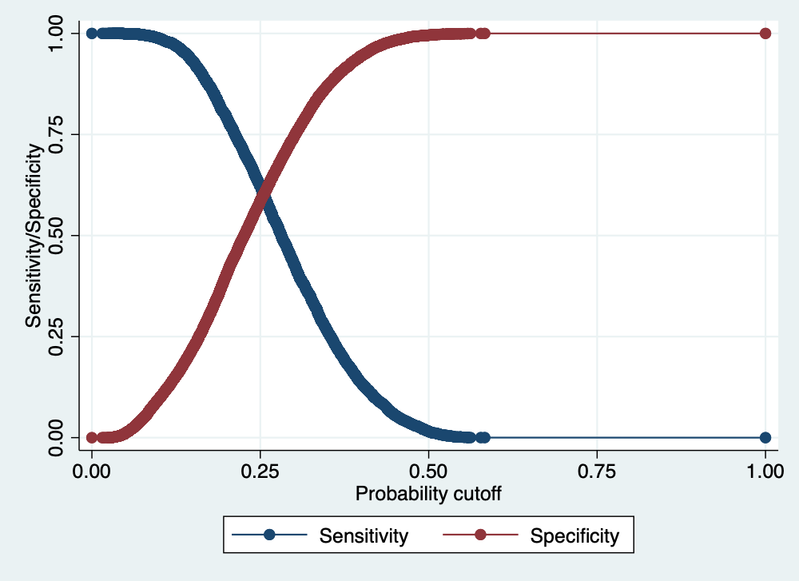

Más valores de ajuste:

```
findit fitstat
```

Para ver el ajuste

```stata
logit pobre_total aproba1 i.r104 ib5.region r106 if r103==1
fitstat
estadd fitstat
estimates store logit1
```

```
Iteration 0:   log likelihood = -11891.073
Iteration 1:   log likelihood = -11291.151
Iteration 2:   log likelihood = -11275.073
Iteration 3:   log likelihood = -11275.059
Iteration 4:   log likelihood = -11275.059

Logistic regression                                    Number of obs =  21,331
                                                       LR chi2(7)    = 1232.03
                                                       Prob > chi2   =  0.0000
Log likelihood = -11275.059                            Pseudo R2     =  0.0518

------------------------------------------------------------------------------
 pobre_total | Coefficient  Std. err.      z    P>|z|     [95% conf. interval]
-------------+----------------------------------------------------------------
     aproba1 |   -.128476    .004288   -29.96   0.000    -.1368802   -.1200717
        r104 |
      mujer  |  -.1420712   .0345934    -4.11   0.000     -.209873   -.0742694
      region |
 occidental  |   .2060723   .0615682     3.35   0.001     .0854008    .3267438
  central i  |   .1262053   .0625852     2.02   0.044     .0035405      .24887
 central ii  |   .2085533   .0649272     3.21   0.001     .0812983    .3358083
   oriental  |   .2142587   .0617314     3.47   0.001     .0932673    .3352501
        r106 |  -.0209154   .0010955   -19.09   0.000    -.0230625   -.0187684
       _cons |   .5034647   .0902672     5.58   0.000     .3265442    .6803852
------------------------------------------------------------------------------


Measures of Fit for logit of pobre_total

Log-Lik Intercept Only:   -11891.073     Log-Lik Full Model:       -11275.059
D(21321):                  22550.117     LR(7):                      1232.029
                                         Prob > LR:                     0.000
McFadden's R2:                 0.052     McFadden's Adj R2:             0.051
Maximum Likelihood R2:         0.056     Cragg & Uhler's R2:            0.084
McKelvey and Zavoina's R2:     0.104     Efron's R2:                    0.053
Variance of y*:                3.674     Variance of error:             3.290
Count R2:                      0.755     Adj Count R2:                  0.002
AIC:                           1.058     AIC*n:                     22570.117
BIC:                     -189975.834     BIC':                      -1162.253

```

[output cut: 21 more lines]

```
           e(r2_mfadj) =  .0509638
              e(r2_ml) =  .05612134
              e(r2_cu) =  .08350704
              e(r2_mz) =  .10443644
              e(r2_ef) =  .05304936
            e(v_ystar) =  3.6735172
            e(v_error) =  3.2898681
              e(r2_ct) =  .75500445
           e(r2_ctadj) =  .00248139
               e(aic0) =  1.05809
              e(aic_n) =  22570.117
               e(bic0) =  -189975.83
              e(bic_p) =  -1162.2532
              e(n_rhs) =  9
             e(n_parm) =  10
```

“estadd” si queremos que se guarden en e() para su uso en “esttab”

Si queremos introducir una variable más, por ejemplo el area de residencia. Podemos introducirla y luego comparar modelos. Muy parecido a F-test, es el lrtest. Sólo que hoy compara tomando en cuenta las devianzas, que están basadas en la maxima verosimilitud

```stata
logit pobre_total aproba1 i.r104 ib5.region r106 i.area if r103==1
estadd fitstat
estimates store logit2
```

```
Iteration 0:   log likelihood = -11891.073
Iteration 1:   log likelihood = -11211.763
Iteration 2:   log likelihood = -11190.853
Iteration 3:   log likelihood =  -11190.83
Iteration 4:   log likelihood =  -11190.83

Logistic regression                                    Number of obs =  21,331
                                                       LR chi2(8)    = 1400.49
                                                       Prob > chi2   =  0.0000
Log likelihood = -11190.83                             Pseudo R2     =  0.0589

------------------------------------------------------------------------------
 pobre_total | Coefficient  Std. err.      z    P>|z|     [95% conf. interval]
-------------+----------------------------------------------------------------
     aproba1 |  -.1438601    .004474   -32.16   0.000    -.1526289   -.1350913
        r104 |
      mujer  |  -.1937378   .0350171    -5.53   0.000    -.2623699   -.1251056
      region |
 occidental  |   .3488809    .062636     5.57   0.000     .2261165    .4716452
  central i  |   .2299571   .0632498     3.64   0.000     .1059898    .3539245
 central ii  |   .3688563   .0662361     5.57   0.000     .2390358    .4986767
   oriental  |   .3835654   .0632084     6.07   0.000     .2596793    .5074515
        r106 |  -.0229387   .0011131   -20.61   0.000    -.0251203   -.0207572
        area |
     urbano  |   .4621418   .0357997    12.91   0.000     .3919758    .5323079
       _cons |    .338888   .0911579     3.72   0.000     .1602219    .5175542
------------------------------------------------------------------------------


Measures of Fit for logit of pobre_total

Log-Lik Intercept Only:   -11891.073     Log-Lik Full Model:       -11190.830
D(21319):                  22381.659     LR(8):                      1400.486
                                         Prob > LR:                     0.000
McFadden's R2:                 0.059     McFadden's Adj R2:             0.058
Maximum Likelihood R2:         0.064     Cragg & Uhler's R2:            0.095
McKelvey and Zavoina's R2:     0.116     Efron's R2:                    0.061
Variance of y*:                3.722     Variance of error:             3.290
Count R2:                      0.754     Adj Count R2:                  0.000
AIC:                           1.050     AIC*n:                     22405.659
```

[output cut: 9 more lines]

```
           e(r2_mfadj) =  .05787899
              e(r2_ml) =  .0635461
              e(r2_cu) =  .09455488
              e(r2_mz) =  .11616935
              e(r2_ef) =  .06131076
            e(v_ystar) =  3.7222834
            e(v_error) =  3.2898681
              e(r2_ct) =  .75444189
           e(r2_ctadj) =  .00019088
               e(aic0) =  1.0503802
              e(aic_n) =  22405.659
               e(bic0) =  -190124.36
              e(bic_p) =  -1320.7432
              e(n_rhs) =  11
             e(n_parm) =  12
```

Comparando:

```stata
lrtest logit1 logit2
```

```
Likelihood-ratio test
Assumption: logit1 nested within logit2

 LR chi2(1) = 168.46
Prob > chi2 = 0.0000
```

Veamos la tabla:

```stata
esttab logit*, eform cells(b(fmt(2) star)) ///
scalars(r2_mf r2_mfadj r2_ml r2_cu dev ll bic aic) ///
starlevel(* 0.10 ** 0.05 *** 0.001) ///
legend label replace unstack
```

```
> scalars(r2_mf r2_mfadj r2_ml r2_cu dev ll bic aic) ///
> starlevel(* 0.10 ** 0.05 *** 0.001) ///
> legend label replace unstack

----------------------------------------------------
                              (1)             (2)
                      pobre_total     pobre_total
                      pobre_total     pobre_total
                                b               b
----------------------------------------------------
número de grados a~s         0.88***         0.87***
hombre                       1.00            1.00
mujer                        0.87***         0.82***
occidental                   1.23***         1.42***
central i                    1.13**          1.26***
central ii                   1.23**          1.45***
oriental                     1.24***         1.47***
Área metropolitana~d         1.00            1.00
edad en años cumpl~s         0.98***         0.98***
rural                                        1.00
urbano                                       1.59***
----------------------------------------------------
Observations                21331           21331
r2_mf                      0.0518          0.0589
r2_mfadj                   0.0510          0.0579
r2_ml                      0.0561          0.0635
r2_cu                      0.0835          0.0946
dev                       22550.1         22381.7
ll                       -11275.1        -11190.8
bic                       22629.9         22471.4
aic                       22566.1         22399.7
----------------------------------------------------
Exponentiated coefficients
* p<0.10, ** p<0.05, *** p<0.001
```

## Análisis de supuestos

La única limitación “real” en la regresión logística es que la variable de respuesta debe ser discreta.

También necesitamos suficiente muestra. El uso de variables discretas requiere que haya suficientes respuestas en cada categoría dada. Si hay demasiadas celdas sin respuesta, las estimaciones de los parámetros y los errores estándar probablemente explotarán. Aquí pues esto lo podemos ver en un análisis descriptivo anterior y ver si podemos juntar categorías.

### Multicolinealiad

La multicolinealidad será un problema porque hará imposible la estimación de máxima verosimilitud. Así como los valores atípicos, siempre pueden generar problemas de estimación. Aquí no podemos usar el VIF, porque sólo sirve para modelos de otro tipo.

```
findit collin
```

```stata
collin aproba1 r104 region r106 area
```

```
(obs=69,876)

  Collinearity Diagnostics

                        SQRT                   R-
  Variable      VIF     VIF    Tolerance    Squared
----------------------------------------------------
   aproba1      1.07    1.04    0.9321      0.0679
      r104      1.00    1.00    0.9972      0.0028
    region      1.02    1.01    0.9801      0.0199
      r106      1.01    1.01    0.9883      0.0117
      area      1.08    1.04    0.9256      0.0744
----------------------------------------------------
  Mean VIF      1.04

                           Cond
        Eigenval          Index
---------------------------------
    1     4.8337          1.0000
    2     0.4339          3.3377
    3     0.3276          3.8412
    4     0.2205          4.6826
    5     0.1453          5.7683
    6     0.0391         11.1238
---------------------------------
 Condition Number        11.1238
 Eigenvalues & Cond Index computed from scaled raw sscp (w/ intercept)
 Det(correlation matrix)    0.9118
```

### valores atípicos

Podemos como siempre utilizar algunos elementos de los modelos lineales.

```stata
predict p
predict stdres, rstand
```

```
(option pr assumed; Pr(pobre_total))
(4,572 missing values generated)

(53,117 missing values generated)
```

Para ver mejor podemos hacer un scatter:

```stata
scatter stdres p
```

[output not shown]

# Post-estimación y cálculo de efecto marginales

Como habíamos mencionado los efectos marginales serán mucho más interesantes en este tipo de modelo

```stata
estimates restore logit2
margins
margins r104
```

```
(results logit2 are active now)


Predictive margins                                      Number of obs = 21,331
Model VCE: OIM

Expression: Pr(pobre_total), predict()

------------------------------------------------------------------------------
             |            Delta-method
             |     Margin   std. err.      z    P>|z|     [95% conf. interval]
-------------+----------------------------------------------------------------
       _cons |    .245605   .0028514    86.14   0.000     .2400164    .2511936
------------------------------------------------------------------------------


Predictive margins                                      Number of obs = 21,331
Model VCE: OIM

Expression: Pr(pobre_total), predict()

------------------------------------------------------------------------------
             |            Delta-method
             |     Margin   std. err.      z    P>|z|     [95% conf. interval]
-------------+----------------------------------------------------------------
        r104 |
     hombre  |   .2582766   .0037116    69.59   0.000      .251002    .2655513
      mujer  |   .2250636   .0045394    49.58   0.000     .2161665    .2339608
------------------------------------------------------------------------------
```

Por *default* nos está dando la probabilidad predicha. Esto es sumamente útil.

Dado que leer los resultados a veces es muy complicados por el concepto de momios, esto puede ayudarnos a comunicar los resultados. Lo ideal es crear “tipos” de individuos en nuestro estudio y comparar las probabilidades.

Una buena idea puede ser guardar estos valores y usar “coefplot” para graficarlos. Para ello debemos utilizar la opción “post” con margins, para que los guardemos como cualquier otra estimación.

Veamos esto con los efectos marginales:

```stata
estimates restore logit2
margins, dydx(*) post
estimates store eff2
```

```
(results logit2 are active now)


Average marginal effects                                Number of obs = 21,331
Model VCE: OIM

Expression: Pr(pobre_total), predict()
dy/dx wrt:  aproba1 2.r104 1.region 2.region 3.region 4.region r106 1.area

------------------------------------------------------------------------------
             |            Delta-method
             |      dy/dx   std. err.      z    P>|z|     [95% conf. interval]
-------------+----------------------------------------------------------------
     aproba1 |  -.0249494   .0007225   -34.53   0.000    -.0263655   -.0235334
        r104 |
      mujer  |   -.033213   .0059227    -5.61   0.000    -.0448214   -.0216046
      region |
 occidental  |   .0574259   .0099703     5.76   0.000     .0378845    .0769673
  central i  |   .0367519   .0099072     3.71   0.000     .0173341    .0561696
 central ii  |   .0610069   .0107199     5.69   0.000     .0399963    .0820174
   oriental  |   .0636633   .0101247     6.29   0.000     .0438193    .0835073
        r106 |  -.0039782   .0001874   -21.23   0.000    -.0043455   -.0036109
        area |
     urbano  |   .0796675   .0060731    13.12   0.000     .0677644    .0915706
------------------------------------------------------------------------------
Note: dy/dx for factor levels is the discrete change from the base level.
```

Ahora con esta estimación la podemos grafica

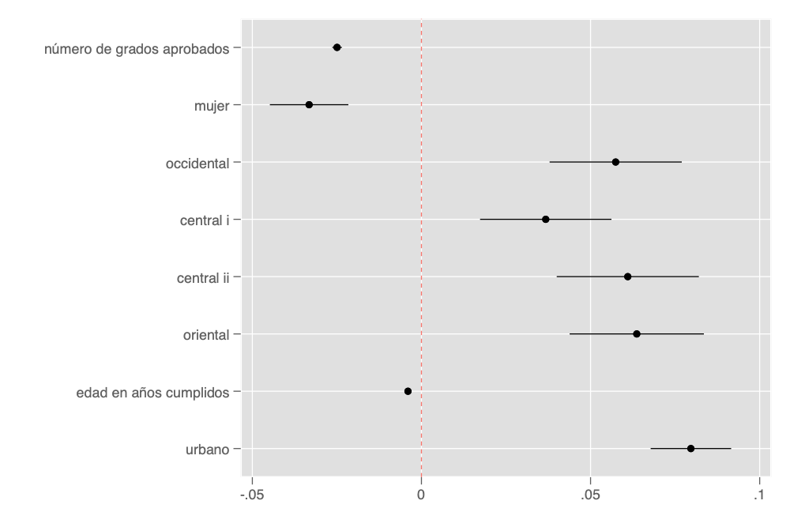

```stata
coefplot eff2, xline(0) scheme(plottig)
```

Más de coefplot y cómo poner los coeficientes http://repec.sowi.unibe.ch/stata/coefplot/getting-started.html#h-4